# hw5

Наташа Ермолаева

25/02/2019

### 5.1

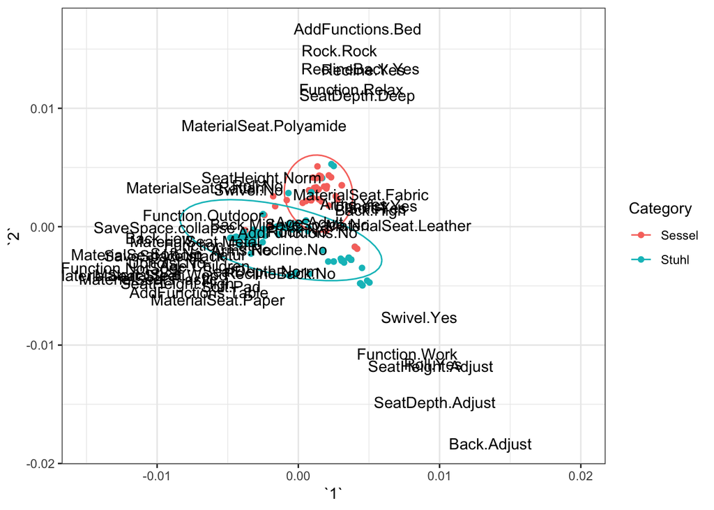

```r
library(magrittr)
library(ggplot2)
library(tibble)

chairs <- read.csv('https://raw.githubusercontent.com/agricolamz/2019_data_analysis_for_linguists/master/data/students/naermolaeva/hw5_CA_MCA/hw5_chairs.csv')

MCA <- MASS::mca(chairs[, !names(chairs) %in% c('Shop', 'WordDE', 'Category')])

data <- cbind(chairs, MCA$rs)
variables <- as_tibble(MCA$cs)
variables$var_names <- rownames(MCA$cs)
data %>%
  ggplot(aes(`1`, `2`))+
  geom_point(aes(color = Category))+
  stat_ellipse(aes(color = Category))+
  geom_text(data = variables, aes(`1`, `2`, label = var_names))+
  theme_bw()+
  scale_x_continuous(limits = c(-0.015, 0.02))
```

### 5.2

На основании полученного графика мы можем сделать вывод о том, что, несмотря на то, что *Sessel* и *Stuhl* **являются различными категориями** (примеры их различий приведены в списке ниже), ряд признаков у данных объектов все-таки оказывается общим (например, *Age.Adult*).

Список некоторых характеристик, которые позволяют **четко разграничить *Sessel* и *Stuhl* между собой**:

| Sessel | Stuhl |
| --- | --- |
| Function.Relax | Function.Eat or Finction.Work |
| SeatDepth.Deep | SeatDepth.Norm |
| Roll.No | Roll.Yes |
| Recline.Yes | Recline.No |
| AddFunctions.Bed | AddFunctions.Table |

### 5.3

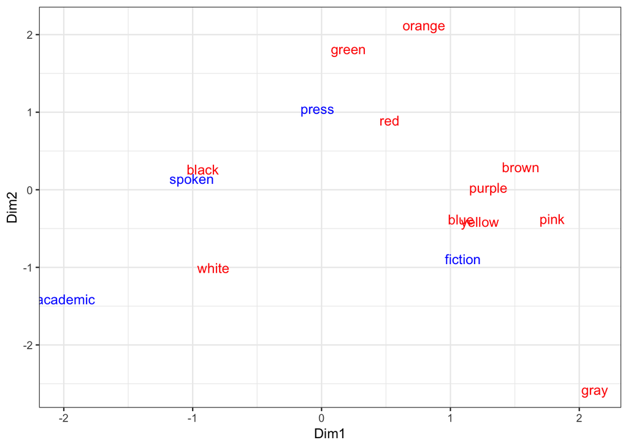

```r
library(ca)

colreg <- read.csv('https://raw.githubusercontent.com/agricolamz/2019_data_analysis_for_linguists/master/data/students/naermolaeva/hw5_CA_MCA/hw5_colreg.csv')

rownames(colreg) <- colreg$colors
ca <- ca(colreg[-5])

colreg_col <- data.frame(ca$colcoord)
colreg_col$rows <- rownames(ca$colcoord)

colreg_row <- data.frame(ca$rowcoord)
colreg_row$rows <- rownames(ca$rowcoord)

colreg_col %>%
  ggplot(aes(Dim1, Dim2, label = rows))+
  geom_text(color = 'blue')+
  geom_text(data = colreg_row, color = 'red')+
  theme_bw()+
  labs(x = 'Dim1',
       y = 'Dim2')
```

### 5.4

Данные для задания 5.3 были взяты из Corpus of Contemporary **American** English. Возможно, в связи с этим, в подкорпусе, состоящем из примеров разговорной (**spoken**) речи, наиболее употребительным является черный цвет (**black**) в силу того, что в США (и в американском английском в целом) употребление слова **black** в отношении темнокожего человека считается абсолютно корректным “правильным”, а именно потому и частотным: *black woman*, *black person*, *black culture*. (Это наблюдение действительно подтверждается поиском по подкорпусу **SPOKEN** в **COCA**).

То же касается и **white**: данное обозначение употребляется по отношению к цвету кожи: *white females*, *white men*, *white race* и др., при этом достаточно равномерно во всех подкорпусах.

Следующий хорошо заметный кластер – это подкорпус художественной литературы (**fiction**), где мы можем заметить наибольшую концентрацию **различных** цветовых обозначений. Вероятно, это связано с тем, что в художественной литературе прилагательные-эпитеты (к которым также относятся и цвета) в целом являются достаточно частотными.

Что касается кластера СМИ (**press**), поиск **orange** по данному подкорпусу (**MAGAZINE**) в **COCA** показывает большое количество примеров, содержащих *Orange Country* (округ в Калифорнии). Возможно, в данном подкорпусе собрано некоторое (и достаточно большое) количество статей из газет/журналов, описывающих какие-либо события, происходящие в данном регионе.

Также для **red** в подкорпусе **press** находим: *red carpet* (в статьях, повествующих о каких-либо официальных церемониях), *red wine* (публикации о(б) употреблении/свойствах красного вина) и др.

Зеленый цвет (**green**) часто употребляется в статьях, содержащих информацию об экологии (в основном), например, *green projects*.

В подкорпусе **academic** цветообозначения в целом употребляются достаточно редко (кроме **white** и **black**, которые, как было показано выше, в подобных текстах чаще всего описывают цвет кожи), так как, кажется, для текстов, написанных в академическом стиле, обычно несвойственно употребление прилагательных, обозначающих цвета.